# Practical Machine Learning Project

William Wan

Thursday, June 18, 2015

The overall strategy was to remove unnecessary columns based on course forums and exploring the initial data. Dividing the training set into smaller folds and running a random forest on a few of these folds revealed other variables that should not be used as classifiers. For example, the row number ended up as the most important variable but was removed after I realized that it was acutally the row number. The num_window factor was also removed after it’s histogram revealed a flat even distribution suggesting that it was randomly distributed amongst the training set.

After training 3 initial models, I took a majority vote bagging apporoach to further refine the predictions.

I used the caret package with the doParallel package model fitting and parallelization

```r
# train$classe contains values of correct movement A-E
library(caret)
# to speed up model training
library(doParallel)
cl <- makeCluster(detectCores())
registerDoParallel(cl)
```

Here, I load the data and split up the training set into 10 even folds so that I have some folds for validation

```r
# load datasets
train_org <- read.csv("pml-training.csv")
test <- read.csv("pml-testing.csv")

train <- train_org # work with a copy of the training set so that we don't have to waste time reloading the original from disk

# create new training and validation sets
folds <- createFolds(y = train$classe, k = 10, list = TRUE)

class_names <- names(train_org) # get list of factor names
```

Here, I clean up the data biy removing columns that we don’t necessarily need. Some columns were removed after using the varImp function to check ‘important’ factors. I ploted the most important factor to make sure it looked non-random. Random factors or factors that were obviously not related (num_window and X) were removed.

```r
col_na_train <- colSums(!is.na(train_org)) # find number of NAs in training set
col_na_test <- colSums(!is.na(test)) # find number of NAs in test set

##### remove NA columns from train dataset
dont_use <- names(col_na_test[!(col_na_test>0)]) # create vector of names with nearly all NAs using test set


for (i in 1 : length(dont_use)) {
  train[, dont_use[i]] <- NULL
}

##### remove unnecessary predictors name, row number, time stamp etc.
train$raw_timestamp_part_1  <- NULL
train$new_window <- NULL # these are mostly "no" - 19216 vs. 406 yes
train$cvtd_timestamp <- NULL

# these were eliminated after looking at varImp and checking histograms of "important' variables
train$X <- NULL
train$num_window <- NULL
```

```r
# set train function to use 10-fold cross-validation repeated 3 times on the training models
# taken from http://topepo.github.io/caret/training.html
fitControl <- trainControl(method = "repeatedcv", number = 10, repeats = 3) # too lazy to write my own CV function

# train on different folds - run multiple times after checking varImp and histograms of important variables
modFit1 <- train(classe ~ ., data = train[folds[1]$Fold01, ], method = "rf", trControl = fitControl)
modFit2 <- train(classe ~ ., data = train[folds[2]$Fold02, ], method = "rf", trControl = fitControl)
modFit3 <- train(classe ~ ., data = train[folds[3]$Fold03, ], method = "rf", trControl = fitControl)

# check importance of variables to see if anything looks out of place
varImp(modFit1)
```

```
## rf variable importance
##
##   only 20 most important variables shown (out of 58)
##
##                   Overall
## roll_belt          100.00
## yaw_belt            77.24
## pitch_forearm       75.24
## magnet_dumbbell_z   74.28
## magnet_dumbbell_y   73.13
## roll_forearm        64.97
## magnet_dumbbell_x   63.10
## accel_belt_z        62.64
## roll_dumbbell       62.46
## pitch_belt          61.51
## accel_dumbbell_y    61.35
## magnet_belt_y       59.81
## magnet_belt_z       59.25
## accel_forearm_x     52.85
## accel_dumbbell_z    51.58
## roll_arm            51.22
## magnet_arm_x        50.34
## accel_dumbbell_x    49.46
## gyros_belt_z        49.40
## accel_arm_x         46.51
```

```r
varImp(modFit2)
```

```
## rf variable importance
##
##   only 20 most important variables shown (out of 58)
##
##                      Overall
## roll_belt             100.00
## pitch_forearm          78.72
## yaw_belt               60.86
## magnet_dumbbell_z      56.10
## magnet_dumbbell_y      47.04
## pitch_belt             38.81
## roll_forearm           32.17
## roll_dumbbell          26.42
## magnet_dumbbell_x      25.17
## accel_dumbbell_y       24.87
## magnet_belt_z          22.08
## accel_belt_z           20.94
## magnet_belt_y          17.74
## yaw_arm                17.48
## accel_forearm_x        17.12
## accel_dumbbell_z       16.26
## yaw_dumbbell           15.47
## magnet_forearm_x       15.26
## magnet_forearm_z       14.99
## total_accel_dumbbell   14.09
```

```r
varImp(modFit3)
```

```
## rf variable importance
##
##   only 20 most important variables shown (out of 58)
##
##                      Overall
## roll_belt             100.00
## pitch_forearm          72.12
## magnet_dumbbell_z      50.74
## yaw_belt               50.32
## pitch_belt             37.82
## magnet_dumbbell_y      35.11
## roll_forearm           33.43
## roll_dumbbell          27.75
## magnet_dumbbell_x      23.78
## accel_dumbbell_y       20.90
## magnet_belt_z          20.40
## accel_dumbbell_x       20.13
## accel_forearm_x        19.41
## magnet_belt_y          19.00
## accel_dumbbell_z       18.26
## magnet_forearm_z       15.59
## accel_belt_z           15.41
## total_accel_dumbbell   13.62
## magnet_belt_x          13.42
## yaw_dumbbell           13.15
```

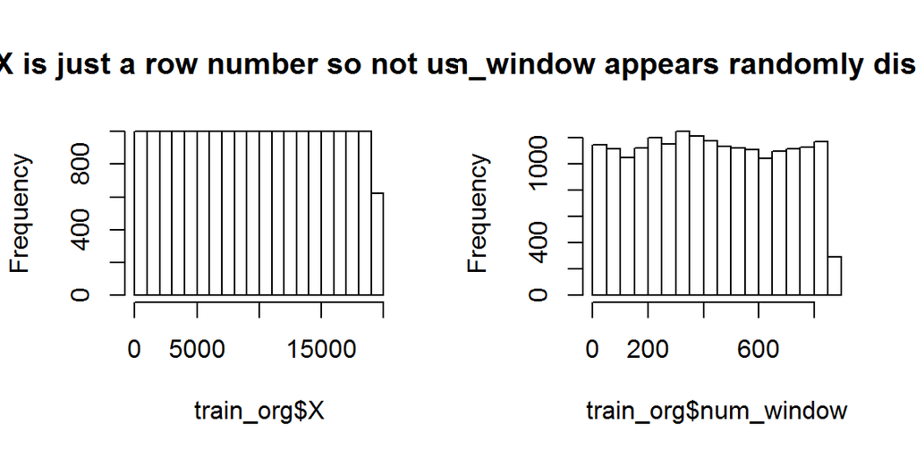

```r
par(mfrow = c(1, 2))
hist(train_org$X, main = "X is just a row number so not usefun")

hist(train_org$num_window, main = "num_window appears randomly distributed")
```

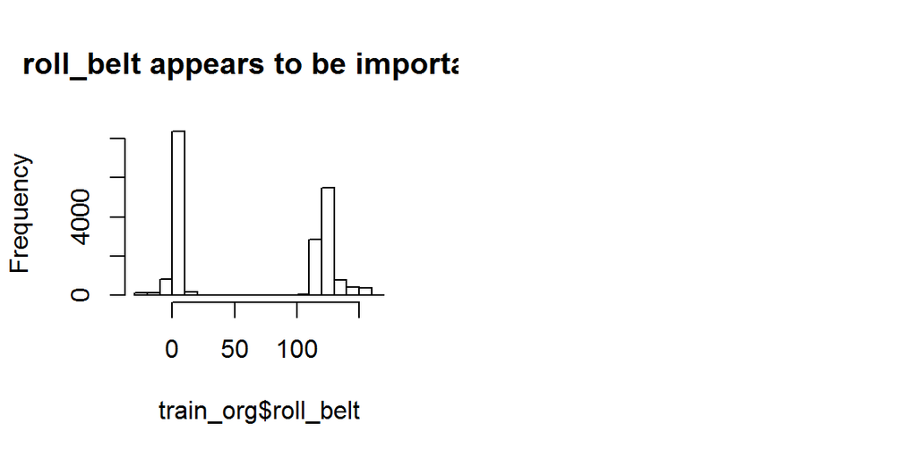

```r
hist(train_org$roll_belt, main = "roll_belt appears to be important")
```

Once I was satisfied that the important variables were truly relevant, I calculated an out of sample error. I took the mean of the out-of-sammple error by using the three models to predict data for three different folds and compared how often my models were correct.

```r
# predict on 3 different valdation sets
pred_train1 <- predict(modFit1, train[folds[4]$Fold04,])
pred_train2 <- predict(modFit2, train[folds[5]$Fold05,])
pred_train3 <- predict(modFit3, train[folds[6]$Fold06,])

# compare predictions with true results of validation sets
oose1 <- (pred_train1 == train[folds[4]$Fold04,]$classe)
oose2 <- (pred_train2 == train[folds[5]$Fold05,]$classe)
oose3 <- (pred_train3 == train[folds[6]$Fold06,]$classe)

# calculate errors
sum(oose1)/length(oose1)
```

```
## [1] 0.9464832
```

```r
sum(oose2)/length(oose2)
```

```
## [1] 0.9551707
```

```r
sum(oose3)/length(oose3)
```

```
## [1] 0.950051
```

This is our average out-of-sample error

```r
oose_tot <- mean(c(oose1, oose2, oose3)) # estimate out-of-sample error is 95%
```

Given an out of sample error of 0.9505691`, I would expect to get 1 out of the 20 test cases wrong. I decided to use a majority vote strategy to estimate the test result, hoping that at least two of the three models would agree on the same answer. Using five or more odd number of models would have been better, but I don’t know how much improvement that would yield.

```r
# predict on test set using different models - use majority vote - hope at least 2/3 are alike
pred_test1 <- predict(modFit1, test)
pred_test2 <- predict(modFit2, test)
pred_test3 <- predict(modFit3, test)

# take majority votes
pred_tot <- data.frame(pred_test1, pred_test2, pred_test3) # create a data frame of predictions

final <- NULL
for (i in 1 : nrow(pred_tot)) { # this results in a vector of numbers
  final[i] <- names(which.max(table(as.character(pred_tot[i,]))))
}

answers <- NULL
for (i in 1 : nrow(pred_tot)) { # convert numbers to letters
  answers[i] <- LETTERS[as.numeric(final[i])]
}

# visually check to see if we correctly calculated the majority
final_answer <- cbind(pred_tot, answers)
```

This is what the final predicted test set looked like along with column indicating the answer picked by the majority of the models.

```r
final_answer
```

```
##    pred_test1 pred_test2 pred_test3 answers
## 1           B          B          B       B
## 2           A          A          A       A
## 3           B          A          A       A
## 4           A          A          A       A
## 5           A          A          A       A
## 6           E          E          E       E
## 7           D          D          D       D
## 8           B          D          D       D
## 9           A          A          A       A
## 10          A          A          A       A
## 11          B          B          B       B
## 12          C          C          C       C
## 13          B          B          B       B
## 14          A          A          A       A
## 15          E          E          E       E
## 16          E          E          E       E
## 17          A          A          A       A
## 18          B          B          B       B
## 19          A          B          B       B
## 20          B          B          B       B
```

```r
# pml_write_files = function(x){
#   n = length(x)
#   for(i in 1:n){
#     filename = paste0("problem_id_",i,".txt")
#     write.table(x[i],file=filename,quote=FALSE,row.names=FALSE,col.names=FALSE)
#   }
# }
#
# pml_write_files(answers)
```